# U.S. National Debt Over Time

## Example API Request

Before requesting the full series of the national debt, we will replicate the example API request from https://fiscaldata.treasury.gov/datasets/monthly-statement-public-debt/.

First, we will specify the base url for the fiscal data API.

```r
urlbase = "https://transparency.treasury.gov/services/api/fiscal_service"
```

Then, we add the endpoint for the “Summary of Treasury Securities Outstanding” table. The paste() function allows for us to concatenate the two strings to create the full url (the sep= option allows for inserting text between the strings being concatenated, which we do not want here).

```r
urlend = "/v1/debt/mspd/mspd_table_1"
urlfull = paste(urlbase,urlend,sep="")
urlfull
```

```
[1] "https://transparency.treasury.gov/services/api/fiscal_service/v1/debt/mspd/mspd_table_1"
```

After we create the full url string, we now want to specify any parameters. For this example, we want to sort the data by date (record_date), specify a JSON response, and retrieve only the first observation after the sorting. The ‘-’ before record_date in the first parameter sorts the dates in descending order so that the most recent observation is at the top. The JSON format option is actually unnecessary as it is the default response format, but if we wanted to receive csv or xml formatted response, we would specify that here. For requesting only the first observation, this consists of two parts: page[size] specifies how any observations in each response and page[number] specifies which ‘page’ to request (if we wanted the second observation, then we would keep page[size] as is and switch to page[number]=2). Note: the first parameter is indicated by ‘?’ and each subsequent parameter is separated with an ‘&’.

```r
opt1 = "?sort=-record_date"
opt2 = "&format=json"
opt3 = "&page[number]=1&page[size]=1"
request1 = paste(urlfull,opt1,opt2,opt3,sep='')
request1
```

```
[1] "https://transparency.treasury.gov/services/api/fiscal_service/v1/debt/mspd/mspd_table_1?sort=-record_date&format=json&page[number]=1&page[size]=1"
```

Now we can request the raw data from the API using the GET() function.

```r
response1 = GET(request1)
response1
```

```
Response [https://www.transparency.treasury.gov/services/api/fiscal_service/v1/debt/mspd/mspd_table_1?sort=-record_date&format=json&page[number]=1&page[size]=1]
  Date: 2020-09-10 00:17
  Status: 200
  Content-Type: application/json
  Size: 2.07 kB
```

Since the content is returned in raw bytes, we must convert this to text, which will output the JSON response as a character array (we can also use rawToChar(response1$content), which will do the same thing).

```r
jsonresponse1 = content(response1,"text")
```

```
No encoding supplied: defaulting to UTF-8.
```

```r
jsonresponse1
```

```
[1] "{\"data\":[{\"record_date\":\"2020-08-31\",\"security_type_desc\":\"Total Nonmarketable\",\"security_class_desc\":\"_\",\"debt_held_public_mil_amt\":\"653089.00\",\"intragov_hold_mil_amt\":\"5885000.00\",\"total_mil_amt\":\"6538089.00\",\"src_line_nbr\":\"14\",\"record_fiscal_year\":\"2020\",\"…
```

Then, to convert this JSON response to something workable in R, we use the fromJSON() function to convert the response to an R data frame, which is the data variable in the converted response (note: use ‘$’ to specify a variable within a data frame).

```r
dfresponse1 = fromJSON(jsonresponse1)
myData1 = dfresponse1$data
myData1
```

|  | record_date | security_type_desc | security_class_desc | debt_held_public_mil_amt | intragov_hold_mil_amt | total_mil_amt | src_line_nbr | record_fiscal_year | record_fiscal_quarter | record_calendar_year | record_calendar_quarter | record_calendar_month | record_calendar_day |
| --- | --- | --- | --- | --- | --- | --- | --- | --- | --- | --- | --- | --- | --- |
| 1 | 2020-08-31 | Total Nonmarketable | _ | 653089.00 | 5885000.00 | 6538089.00 | 14 | 2020 | 4 | 2020 | 3 | 08 | 31 |

**Alternatively, we could simply use the fromJSON() function on request1, which will cut out the intermediate steps (note: myData1 and myData are identical).**

```r
dfresponse = fromJSON(request1)
myData = dfresponse$data
myData
```

|  | record_date | security_type_desc | security_class_desc | debt_held_public_mil_amt | intragov_hold_mil_amt | total_mil_amt | src_line_nbr | record_fiscal_year | record_fiscal_quarter | record_calendar_year | record_calendar_quarter | record_calendar_month | record_calendar_day |
| --- | --- | --- | --- | --- | --- | --- | --- | --- | --- | --- | --- | --- | --- |
| 1 | 2020-08-31 | Total Nonmarketable | _ | 653089.00 | 5885000.00 | 6538089.00 | 14 | 2020 | 4 | 2020 | 3 | 08 | 31 |

Now that we’ve imported the data into a R data frame, we need to format the variables using the “as” function. If we use class() to retrieve the variable type for each variable, everything is imported as character arrays.

```r
class(myData$record_date)
```

```
[1] "character"
```

```r
class(myData$security_type_desc)
```

```
[1] "character"
```

```r
class(myData$debt_held_public_mil_amt)
```

```
[1] "character"
```

```r
myData$debt_held_public_mil_amt/2
```

```
Error in myData$debt_held_public_mil_amt/2 :
  non-numeric argument to binary operator
```

For this example, we will just format one date and one numeric variable.

```r
myData$record_date = as.Date(myData$record_date)
class(myData$record_date)
```

```
[1] "Date"
```

```r
myData$debt_held_public_mil_amt = as.numeric(myData$debt_held_public_mil_amt)
class(myData$debt_held_public_mil_amt)
```

```
[1] "numeric"
```

```r
myData$debt_held_public_mil_amt/2
```

```
[1] 326544.5
```

## Full API Request

Now that we have worked through the example API request, let’s move on to our project’s goal of importing the full series of national debt observations.

First, we need to adjust our parameters to reflect this new request. We will reuse opt1 from request1 to sort the observations. The next parameter specifies the variables that we want (the last seven variables are mostly redundant so we omit them). The third parameter specifies that we want all of the observations returned in this request (we do this by specifying a large number for page[size])

```r
req2opt1 = opt1
req2opt2 = "&fields=record_date,security_type_desc,security_class_desc,debt_held_public_mil_amt,intragov_hold_mil_amt,total_mil_amt"
req2opt3 = "&page[size]=10000"
request2 = paste(urlfull,req2opt1,req2opt2,req2opt3,sep="")
```

Now make the request and save the response using fromJSON().

```r
dfresponse2 = fromJSON(request2)
```

Next, extract the data frame and format the variables. Lastly, print the first 20 observations of the data frame to get a better feel for the layout.

```r
debtdf = dfresponse2$data
debtdf$record_date = as.Date(debtdf$record_date)
debtdf$debt_held_public_mil_amt = as.numeric(debtdf$debt_held_public_mil_amt)
debtdf$intragov_hold_mil_amt = as.numeric(debtdf$intragov_hold_mil_amt)
debtdf$total_mil_amt = as.numeric(debtdf$total_mil_amt)
head(debtdf,20)
```

|  | record_date | security_type_desc | security_class_desc | debt_held_public_mil_amt | intragov_hold_mil_amt | total_mil_amt |
| --- | --- | --- | --- | --- | --- | --- |
| 1 | 2020-08-31 | Marketable | Federal Financing Bank | 0 | 7262 | 7262 |
| 2 | 2020-08-31 | Nonmarketable | Government Account Series | 289279 | 5885000 | 6174279 |
| 3 | 2020-08-31 | Marketable | Notes | 10516332 | 7700 | 10524032 |
| 4 | 2020-08-31 | Nonmarketable | Other | 2474 | 0 | 2474 |
| 5 | 2020-08-31 | Total Public Debt Outstanding | _ | 20822038 | 5906797 | 26728836 |
| 6 | 2020-08-31 | Nonmarketable | Foreign Series | 264 | 0 | 264 |
| 7 | 2020-08-31 | Marketable | Bills | 5075875 | 847 | 5076721 |
| 8 | 2020-08-31 | Marketable | Treasury Inflation-Protected Securities | 1501097 | 775 | 1501872 |
| 9 | 2020-08-31 | Total Nonmarketable | _ | 653089 | 5885000 | 6538089 |
| 10 | 2020-08-31 | Nonmarketable | State and Local Government Series | 95901 | 0 | 95901 |

[output cut: 10 more lines]

To make our figures a little cleaner later, we will also create a new variable that converts the units of the national debt into trillions of $USD, rather than millions.

```r
debtdf$total_tril_amt = debtdf$total_mil_amt/1000000
```

Since the table contains observations for the total national debt along with various subsets, we need to extract the subset of observations corresponding with total debt figures. As with many things in R, there are multiple ways to do this. Two examples the yield identical results are:

```r
totaldebtdf = debtdf[which(debtdf$security_type_desc=="Total Public Debt Outstanding"),names(debtdf)]
totaldebtdf2 = subset(debtdf,security_type_desc=="Total Public Debt Outstanding",names(debtdf))
```

```r
head(totaldebtdf,10)
```

|  | record_date | security_type_desc | security_class_desc | debt_held_public_mil_amt | intragov_hold_mil_amt | total_mil_amt | total_tril_amt |
| --- | --- | --- | --- | --- | --- | --- | --- |
| 5 | 2020-08-31 | Total Public Debt Outstanding | _ | 20822038 | 5906797 | 26728836 | 26.72884 |
| 19 | 2020-07-31 | Total Public Debt Outstanding | _ | 20634400 | 5890554 | 26524953 | 26.52495 |
| 38 | 2020-06-30 | Total Public Debt Outstanding | _ | 20530278 | 5946963 | 26477241 | 26.47724 |
| 52 | 2020-05-31 | Total Public Debt Outstanding | _ | 19812782 | 5933479 | 25746260 | 25.74626 |
| 63 | 2020-04-30 | Total Public Debt Outstanding | _ | 19053619 | 5920553 | 24974172 | 24.97417 |
| 80 | 2020-03-31 | Total Public Debt Outstanding | _ | 17674771 | 6012100 | 23686871 | 23.68687 |
| 103 | 2020-02-29 | Total Public Debt Outstanding | _ | 17413050 | 5996909 | 23409959 | 23.40996 |
| 108 | 2020-01-31 | Total Public Debt Outstanding | _ | 17212635 | 6011178 | 23223813 | 23.22381 |
| 135 | 2019-12-31 | Total Public Debt Outstanding | _ | 17170442 | 6030938 | 23201380 | 23.20138 |
| 136 | 2019-11-30 | Total Public Debt Outstanding | _ | 17105421 | 5970778 | 23076199 | 23.07620 |

## Plotting the Data

### Simple Line Chart

To plot out the national debt over time, we will use the plot() function, and a few options to set some labels, which creates a simple line chart plotting the time series.

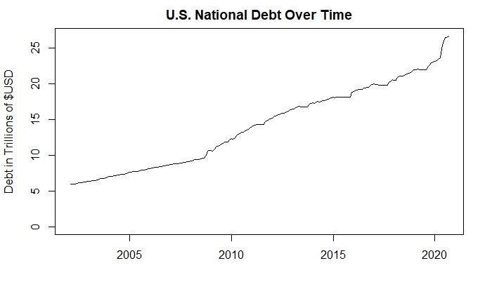

```r
plot(totaldebtdf$record_date,totaldebtdf$total_tril_amt,type='l',main="U.S. National Debt Over Time",xlab="",ylab="Debt in Trillions of $USD",ylim=c(0,max(totaldebtdf$total_tril_amt)))
```

### Stacked Line Chart 1: Publicly Held Debt vs. Intragovernmental Holdings

To compare across publicly held debt and intragovernmental holdings, we must first combine the two variables together using the gather() function, convert to trillions, and then plot the stacked area chart using ggplot() along with a few labeling options.

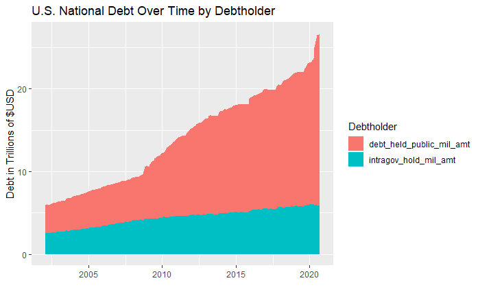

```r
helddf = totaldebtdf[,c("record_date","debt_held_public_mil_amt","intragov_hold_mil_amt")]
helddf = gather(helddf,"Holder","mil_amt",-record_date)
helddf$tril_amt = helddf$mil_amt/1000000
ggplot(helddf, aes(x = record_date, y = tril_amt, fill = Holder)) + geom_area(position = 'stack') + xlab("") + ylab("Debt in Trillions of $USD") + labs(title="U.S. National Debt Over Time by Debtholder",fill="Debtholder")
```

### Stacked Line Chart 2: Debt by Marketability

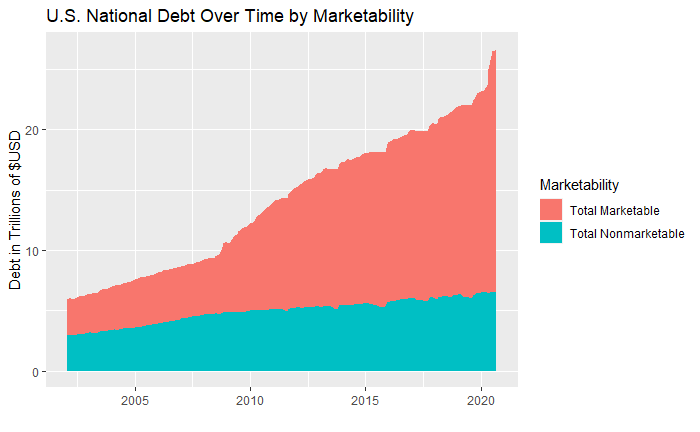

```r
stackdf = subset(debtdf,security_type_desc%in%c("Total Marketable","Total Nonmarketable"),names(debtdf))
ggplot(stackdf, aes(x = record_date, y = total_tril_amt, fill = security_type_desc)) + geom_area(position = 'stack') + xlab("") + ylab("Debt in Trillions of $USD") + labs(title="U.S. National Debt Over Time by Marketability",fill="Marketability")
```

### Stacked Line Chart 3: Debt by Security Class

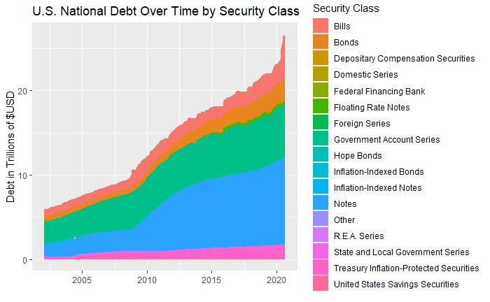

```r
secclassdf = subset(debtdf,security_class_desc!="_",names(debtdf))
ggplot(secclassdf, aes(x = record_date, y = total_tril_amt, fill = security_class_desc)) + geom_area(position = 'stack') + xlab("") + ylab("Debt in Trillions of $USD") + labs(title="U.S. National Debt Over Time by Security Class",fill="Security Class")
```